# SHRS Education Analysis — 2023 Entry Requirements & Training (Table 5.4)

SHRS MQE Capstone Team

2026-02-13

```r
library(tidyverse)
library(scales)
library(knitr)
library(kableExtra)
```

# 0 — Configuration

```r
# ── EDIT THIS PATH ──
CSV_PATH <- file.path(path.expand("~"), "Documents", "SHRS_Analysis",
                       "market_analysis", "v3data", "projections_csv",
                       "education_csv", "2023",
                       "education_2023 - Table 5.4.csv")

# 9-program crosswalk
soc_xwalk <- tribble(
  ~shrs_program, ~shrs_dept, ~soc_code,
  "SLP", "CSD", "29-1127",
  "AuD", "CSD", "29-1181",
  "HIM", "HIM", "29-9021",
  "OTD", "RST", "29-1122",
  "DPT", "RST", "29-1123",
  "PAS", "PAS", "29-1071",
  "AT",  "SMN", "29-9091",
  "DN",  "SMN", "29-1031",
  "SS",  "SMN", "29-1128"
)

target_socs <- soc_xwalk$soc_code

program_colors <- c(
  "SLP" = "#2c7bb6", "AuD" = "#abd9e9", "HIM" = "#8e44ad",
  "OTD" = "#e67e22", "DPT" = "#16a085", "PAS" = "#c0392b",
  "AT"  = "#fdae61", "DN"  = "#d7191c", "SS"  = "#1a9641"
)
signal_colors <- c("Green" = "#27ae60", "Yellow" = "#f39c12", "Red" = "#e74c3c")
```

# 1 — Load & Clean

```r
raw <- read_csv(CSV_PATH, show_col_types = FALSE)

names(raw)[1] <- "occ_title"
names(raw)[2] <- "soc_code"
names(raw)[3] <- "entry_education"
names(raw)[4] <- "work_experience"
names(raw)[5] <- "ojt_required"

if (ncol(raw) >= 6) raw <- raw |> select(1:5)

raw <- raw |>
  mutate(
    soc_code  = str_trim(soc_code),
    occ_title = str_remove_all(occ_title, "\\[\\d+\\]") |> str_trim()
  )

shrs_t54 <- raw |>
  filter(soc_code %in% target_socs) |>
  left_join(soc_xwalk, by = "soc_code")
```

### Data Quality Check

```r
cat(paste0("**Programs found:** ", nrow(shrs_t54), " of 9\n\n"))
```

**Programs found:** 9 of 9

```r
for (i in seq_len(nrow(shrs_t54))) {
  cat(paste0("- ", shrs_t54$shrs_program[i], ": ",
             shrs_t54$entry_education[i], "\n"))
}
```

- DN: Bachelor’s degree
- PAS: Master’s degree
- OTD: Master’s degree
- DPT: Doctoral or professional degree
- SLP: Master’s degree
- SS: Bachelor’s degree
- AuD: Doctoral or professional degree
- HIM: Associate’s degree
- AT: Master’s degree

# 2 — Entry Education Requirements (2023)

```r
shrs_t54 |>
  select(Program = shrs_program, Dept = shrs_dept,
         `Entry Education` = entry_education,
         `Work Experience` = work_experience,
         `OJT Required` = ojt_required) |>
  arrange(factor(Program, levels = soc_xwalk$shrs_program)) |>
  kable(caption = "BLS Education & Training Requirements (2023)") |>
  kable_styling(bootstrap_options = c("striped", "hover"), full_width = FALSE)
```

BLS Education & Training Requirements (2023)

| Program | Dept | Entry Education | Work Experience | OJT Required |
| --- | --- | --- | --- | --- |
| SLP | CSD | Master’s degree | None | Internship/residency |
| AuD | CSD | Doctoral or professional degree | None | None |
| HIM | HIM | Associate’s degree | None | None |
| OTD | RST | Master’s degree | None | None |
| DPT | RST | Doctoral or professional degree | None | None |
| PAS | PAS | Master’s degree | None | None |
| AT | SMN | Master’s degree | None | None |
| DN | SMN | Bachelor’s degree | None | Internship/residency |
| SS | SMN | Bachelor’s degree | None | None |

## 2.1 Education Tiers

```r
shrs_t54 <- shrs_t54 |>
  mutate(
    edu_tier = case_when(
      entry_education == "Doctoral or professional degree" ~ 4,
      entry_education == "Master's degree"                 ~ 3,
      entry_education == "Bachelor's degree"                ~ 2,
      entry_education == "Associate's degree"               ~ 1,
      TRUE                                                  ~ 0
    ),
    tier_label = case_when(
      edu_tier == 4 ~ "Doctoral",
      edu_tier == 3 ~ "Master's",
      edu_tier == 2 ~ "Bachelor's",
      edu_tier == 1 ~ "Associate's",
      TRUE          ~ "Below Associate's"
    ),
    edu_years = case_when(
      entry_education == "Doctoral or professional degree" ~ 21,
      entry_education == "Master's degree"                 ~ 18,
      entry_education == "Bachelor's degree"                ~ 16,
      entry_education == "Associate's degree"               ~ 14,
      TRUE                                                  ~ 12
    )
  )
```

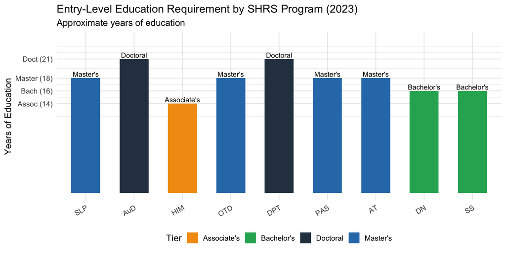

```r
shrs_t54 |>
  ggplot(aes(x = factor(shrs_program, levels = soc_xwalk$shrs_program),
             y = edu_years, fill = tier_label)) +
  geom_col(width = 0.6) +
  geom_text(aes(label = tier_label), vjust = -0.3, size = 3.5) +
  scale_fill_manual(values = c("Doctoral" = "#2c3e50", "Master's" = "#2c7bb6",
                                "Bachelor's" = "#27ae60", "Associate's" = "#f39c12"),
                    name = "Tier") +
  scale_y_continuous(limits = c(0, 24),
                     breaks = c(14, 16, 18, 21),
                     labels = c("Assoc (14)", "Bach (16)",
                                "Master (18)", "Doct (21)")) +
  labs(
    title = "Entry-Level Education Requirement by SHRS Program (2023)",
    subtitle = "Approximate years of education",
    x = NULL, y = "Years of Education"
  ) +
  theme_minimal(base_size = 13) +
  theme(axis.text.x = element_text(angle = 30, hjust = 1),
        legend.position = "bottom")
```

# 3 — Training Burden Analysis (2023)

```r
shrs_t54 <- shrs_t54 |>
  mutate(
    edu_burden = case_when(
      entry_education == "Doctoral or professional degree" ~ 3,
      entry_education == "Master's degree"                 ~ 2,
      entry_education == "Bachelor's degree"                ~ 1,
      entry_education == "Associate's degree"               ~ 0,
      TRUE                                                  ~ 0
    ),
    exp_burden = case_when(
      work_experience == "5 years or more"  ~ 3,
      work_experience == "Less than 5 years" ~ 2,
      work_experience == "None"              ~ 0,
      TRUE                                    ~ 0
    ),
    ojt_burden = case_when(
      str_detect(ojt_required, regex("long-term", ignore_case = TRUE))          ~ 3,
      str_detect(ojt_required, regex("moderate", ignore_case = TRUE))           ~ 2,
      str_detect(ojt_required, regex("internship|residency", ignore_case = TRUE)) ~ 2,
      str_detect(ojt_required, regex("short-term", ignore_case = TRUE))         ~ 1,
      ojt_required == "None"                                                     ~ 0,
      TRUE                                                                        ~ 0
    ),
    total_burden = edu_burden + exp_burden + ojt_burden
  )
```

```r
shrs_t54 |>
  select(Program = shrs_program,
         `Entry Ed` = entry_education,
         `Work Exp` = work_experience,
         `OJT` = ojt_required,
         `Edu (0-3)` = edu_burden,
         `Exp (0-3)` = exp_burden,
         `OJT (0-3)` = ojt_burden,
         `Total (0-9)` = total_burden) |>
  arrange(factor(Program, levels = soc_xwalk$shrs_program)) |>
  kable(caption = "Training Burden Scores (2023)") |>
  kable_styling(bootstrap_options = c("striped", "hover"), full_width = FALSE)
```

Training Burden Scores (2023)

| Program | Entry Ed | Work Exp | OJT | Edu (0-3) | Exp (0-3) | OJT (0-3) | Total (0-9) |
| --- | --- | --- | --- | --- | --- | --- | --- |
| SLP | Master’s degree | None | Internship/residency | 2 | 0 | 2 | 4 |
| AuD | Doctoral or professional degree | None | None | 3 | 0 | 0 | 3 |
| HIM | Associate’s degree | None | None | 0 | 0 | 0 | 0 |
| OTD | Master’s degree | None | None | 2 | 0 | 0 | 2 |
| DPT | Doctoral or professional degree | None | None | 3 | 0 | 0 | 3 |
| PAS | Master’s degree | None | None | 2 | 0 | 0 | 2 |
| AT | Master’s degree | None | None | 2 | 0 | 0 | 2 |
| DN | Bachelor’s degree | None | Internship/residency | 1 | 0 | 2 | 3 |
| SS | Bachelor’s degree | None | None | 1 | 0 | 0 | 1 |

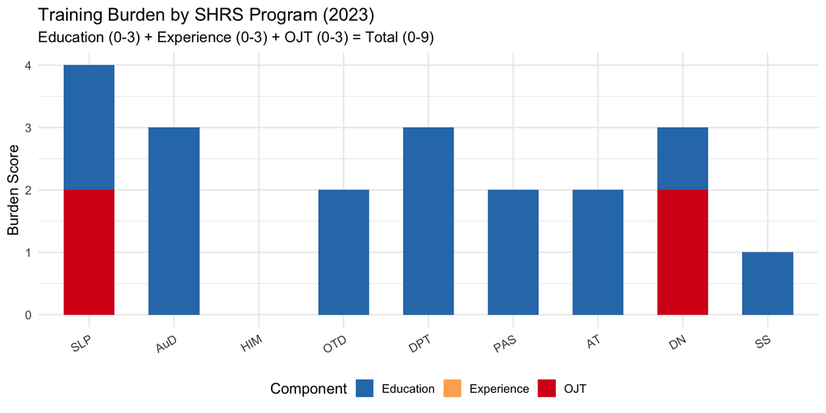

```r
shrs_t54 |>
  select(shrs_program, edu_burden, exp_burden, ojt_burden) |>
  pivot_longer(-shrs_program, names_to = "component", values_to = "score") |>
  mutate(component = case_when(
    component == "edu_burden" ~ "Education",
    component == "exp_burden" ~ "Experience",
    component == "ojt_burden" ~ "OJT"
  )) |>
  ggplot(aes(x = factor(shrs_program, levels = soc_xwalk$shrs_program),
             y = score, fill = component)) +
  geom_col(width = 0.6) +
  scale_fill_manual(values = c("Education" = "#2c7bb6",
                                "Experience" = "#fdae61",
                                "OJT" = "#d7191c"),
                    name = "Component") +
  labs(
    title = "Training Burden by SHRS Program (2023)",
    subtitle = "Education (0-3) + Experience (0-3) + OJT (0-3) = Total (0-9)",
    x = NULL, y = "Burden Score"
  ) +
  theme_minimal(base_size = 13) +
  theme(axis.text.x = element_text(angle = 30, hjust = 1),
        legend.position = "bottom")
```

# 4 — Entry Requirements Scorecard (0–100)

```r
shrs_t54 <- shrs_t54 |>
  mutate(
    d1_training_simple = round((1 - total_burden / 9) * 100, 1),
    d2_exp_accessible  = round((1 - exp_burden / 3) * 100, 1),
    composite = round((d1_training_simple + d2_exp_accessible) / 2, 1),
    signal = case_when(
      composite >= 70 ~ "Green",
      composite >= 50 ~ "Yellow",
      TRUE            ~ "Red"
    )
  )
```

```r
sc_ordered <- shrs_t54 |> arrange(desc(composite))

sc_ordered |>
  select(Program = shrs_program,
         `Entry Ed` = entry_education,
         `Train Simple (0-100)` = d1_training_simple,
         `Exp Access (0-100)` = d2_exp_accessible,
         Composite = composite,
         Signal = signal) |>
  kable(digits = 1,
        caption = "Entry Requirements Scorecard (0-100, 2023)") |>
  kable_styling(bootstrap_options = c("striped", "hover"), full_width = FALSE) |>
  column_spec(6, color = "white",
              background = ifelse(sc_ordered$signal == "Green", "#27ae60",
                           ifelse(sc_ordered$signal == "Yellow", "#f39c12",
                                  "#e74c3c")))
```

Entry Requirements Scorecard (0-100, 2023)

| Program | Entry Ed | Train Simple (0-100) | Exp Access (0-100) | Composite | Signal |
| --- | --- | --- | --- | --- | --- |
| HIM | Associate’s degree | 100.0 | 100 | 100.0 | Green |
| SS | Bachelor’s degree | 88.9 | 100 | 94.4 | Green |
| PAS | Master’s degree | 77.8 | 100 | 88.9 | Green |
| OTD | Master’s degree | 77.8 | 100 | 88.9 | Green |
| AT | Master’s degree | 77.8 | 100 | 88.9 | Green |
| DN | Bachelor’s degree | 66.7 | 100 | 83.3 | Green |
| DPT | Doctoral or professional degree | 66.7 | 100 | 83.3 | Green |
| AuD | Doctoral or professional degree | 66.7 | 100 | 83.3 | Green |
| SLP | Master’s degree | 55.6 | 100 | 77.8 | Green |

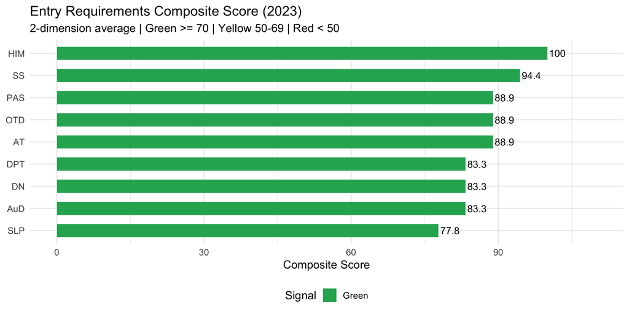

```r
shrs_t54 |>
  ggplot(aes(x = reorder(shrs_program, composite), y = composite,
             fill = signal)) +
  geom_col(width = 0.6) +
  geom_text(aes(label = composite), hjust = -0.1, size = 4) +
  coord_flip() +
  scale_fill_manual(values = signal_colors, name = "Signal") +
  scale_y_continuous(limits = c(0, 110)) +
  labs(
    title = "Entry Requirements Composite Score (2023)",
    subtitle = "2-dimension average | Green >= 70 | Yellow 50-69 | Red < 50",
    x = NULL, y = "Composite Score"
  ) +
  theme_minimal(base_size = 13) +
  theme(legend.position = "bottom")
```

# 5 — Stability Check: 2023 vs 2024 Entry Requirements

This section compares the 2023 assignments against 2024 to flag any BLS reclassifications.

```r
# Load 2024 Table 5.4 for comparison
T54_2024_PATH <- file.path(path.expand("~"), "Documents", "SHRS_Analysis",
                            "market_analysis", "v3data", "projections_csv",
                            "education_csv", "2024",
                            "education - Table 5.4.csv")

if (file.exists(T54_2024_PATH)) {
  raw_2024 <- read_csv(T54_2024_PATH, show_col_types = FALSE)
  names(raw_2024)[1] <- "occ_title"
  names(raw_2024)[2] <- "soc_code"
  names(raw_2024)[3] <- "entry_education"
  names(raw_2024)[4] <- "work_experience"
  names(raw_2024)[5] <- "ojt_required"

  cmp_2024 <- raw_2024 |>
    mutate(soc_code = str_trim(soc_code)) |>
    filter(soc_code %in% target_socs) |>
    left_join(soc_xwalk, by = "soc_code") |>
    select(shrs_program, entry_2024 = entry_education,
           exp_2024 = work_experience, ojt_2024 = ojt_required)

  cmp_2023 <- shrs_t54 |>
    select(shrs_program, entry_2023 = entry_education,
           exp_2023 = work_experience, ojt_2023 = ojt_required)

  stability <- cmp_2023 |>
    left_join(cmp_2024, by = "shrs_program") |>
    mutate(
      edu_changed = entry_2023 != entry_2024,
      exp_changed = exp_2023 != exp_2024,
      ojt_changed = ojt_2023 != ojt_2024
    )

  any_changes <- any(stability$edu_changed | stability$exp_changed |
                     stability$ojt_changed)

  if (any_changes) {
    cat("**Changes detected between 2023 and 2024 vintages:**\n\n")
    changed <- stability |>
      filter(edu_changed | exp_changed | ojt_changed)
    for (j in seq_len(nrow(changed))) {
      r <- changed[j, ]
      cat(paste0("- **", r$shrs_program, "**: "))
      if (r$edu_changed) cat(paste0("Entry ed: ", r$entry_2023, " -> ", r$entry_2024, " "))
      if (r$exp_changed) cat(paste0("Exp: ", r$exp_2023, " -> ", r$exp_2024, " "))
      if (r$ojt_changed) cat(paste0("OJT: ", r$ojt_2023, " -> ", r$ojt_2024, " "))
      cat("\n")
    }
  } else {
    cat("**No changes detected** between 2023 and 2024 vintages. All entry ",
        "education, work experience, and OJT assignments are identical.\n")
  }

  t54_stability_data <- stability
} else {
  cat("*2024 Table 5.4 file not found — skipping stability check.*\n")
}
```

**No changes detected** between 2023 and 2024 vintages. All entry education, work experience, and OJT assignments are identical.

# 6 — Stored Outputs

```r
t54_2023_data       <- shrs_t54
t54_2023_scorecard  <- shrs_t54 |>
  select(shrs_program, shrs_dept, soc_code, entry_education,
         work_experience, ojt_required, edu_tier, tier_label, edu_years,
         edu_burden, exp_burden, ojt_burden, total_burden,
         d1_training_simple, d2_exp_accessible, composite, signal)
```

```r
cat("| Variable | Description | Dimensions |\n")
```

Variable | Description | Dimensions |

```r
cat("|---|---|---|\n")
```

[output not shown]

```r
cat(paste0("| `t54_2023_data` | Full Table 5.4 data with tiers and burden scores | ",
           nrow(t54_2023_data), " x ", ncol(t54_2023_data), " |\n"))
```

`t54_2023_data` | Full Table 5.4 data with tiers and burden scores | 9 x 18 |

```r
cat(paste0("| `t54_2023_scorecard` | Entry requirements scorecard (0-100) | ",
           nrow(t54_2023_scorecard), " x ", ncol(t54_2023_scorecard), " |\n"))
```

`t54_2023_scorecard` | Entry requirements scorecard (0-100) | 9 x 17 |

```r
if (exists("t54_stability_data")) {
  cat(paste0("| `t54_stability_data` | 2023 vs 2024 comparison with change flags | ",
             nrow(t54_stability_data), " x ", ncol(t54_stability_data), " |\n"))
}
```

`t54_stability_data` | 2023 vs 2024 comparison with change flags | 9 x 10 |

# Appendix

**Source:** BLS Employment Projections, Table 5.4 — Education and training assignments by detailed occupation, 2023 vintage.

**Scoring:** Same methodology as 2024 file for direct comparison.

- Training Simplicity: (1 - total_burden / 9) * 100
- Experience Accessibility: (1 - exp_burden / 3) * 100
- Composite: average of both

**Signals:** Green >= 70 | Yellow 50-69 | Red < 50